# Risk Factor Analysis

## Outcome Variable

**Outcome Variable:** stunted

## Predictor Variables

**Intervention Variable:** fhtcm

**Adjustment Set:**

- arm
- W_mage
- W_fage
- meducyrs
- feducyrs
- W_mhtcm
- W_mwtkg
- W_mbmi
- single
- delta_W_mage
- delta_W_fage
- delta_meducyrs
- delta_feducyrs
- delta_W_mhtcm
- delta_W_mwtkg
- delta_W_mbmi
- delta_single

## Stratifying Variables

The analysis was stratified on these variable(s):

- agecat
- studyid
- country

## Data Summary

| agecat | studyid | country | fhtcm | stunted | n_cell | n |
| --- | --- | --- | --- | --- | --- | --- |
| 6 months | ki1000304b-SAS-CompFeed | INDIA | [160-170) | 0 | 328 | 807 |
| 6 months | ki1000304b-SAS-CompFeed | INDIA | [160-170) | 1 | 134 | 807 |
| 6 months | ki1000304b-SAS-CompFeed | INDIA | <160 | 0 | 71 | 807 |
| 6 months | ki1000304b-SAS-CompFeed | INDIA | <160 | 1 | 43 | 807 |
| 6 months | ki1000304b-SAS-CompFeed | INDIA | >=170 | 0 | 179 | 807 |
| 6 months | ki1000304b-SAS-CompFeed | INDIA | >=170 | 1 | 52 | 807 |
| Birth | ki1000304b-SAS-CompFeed | INDIA | [160-170) | 0 | 50 | 102 |
| Birth | ki1000304b-SAS-CompFeed | INDIA | [160-170) | 1 | 15 | 102 |
| Birth | ki1000304b-SAS-CompFeed | INDIA | <160 | 0 | 7 | 102 |
| Birth | ki1000304b-SAS-CompFeed | INDIA | <160 | 1 | 4 | 102 |
| Birth | ki1000304b-SAS-CompFeed | INDIA | >=170 | 0 | 18 | 102 |
| Birth | ki1000304b-SAS-CompFeed | INDIA | >=170 | 1 | 8 | 102 |
| 6 months | ki1000304b-SAS-FoodSuppl | INDIA | [160-170) | 0 | 135 | 372 |
| 6 months | ki1000304b-SAS-FoodSuppl | INDIA | [160-170) | 1 | 90 | 372 |
| 6 months | ki1000304b-SAS-FoodSuppl | INDIA | <160 | 0 | 45 | 372 |
| 6 months | ki1000304b-SAS-FoodSuppl | INDIA | <160 | 1 | 49 | 372 |
| 6 months | ki1000304b-SAS-FoodSuppl | INDIA | >=170 | 0 | 33 | 372 |
| 6 months | ki1000304b-SAS-FoodSuppl | INDIA | >=170 | 1 | 20 | 372 |
| Birth | ki1101329-Keneba | GAMBIA | [160-170) | 0 | 598 | 1165 |
| Birth | ki1101329-Keneba | GAMBIA | [160-170) | 1 | 33 | 1165 |
| Birth | ki1101329-Keneba | GAMBIA | <160 | 0 | 24 | 1165 |
| Birth | ki1101329-Keneba | GAMBIA | <160 | 1 | 3 | 1165 |
| Birth | ki1101329-Keneba | GAMBIA | >=170 | 0 | 485 | 1165 |
| Birth | ki1101329-Keneba | GAMBIA | >=170 | 1 | 22 | 1165 |
| 6 months | ki1101329-Keneba | GAMBIA | [160-170) | 0 | 692 | 1511 |
| 6 months | ki1101329-Keneba | GAMBIA | [160-170) | 1 | 136 | 1511 |
| 6 months | ki1101329-Keneba | GAMBIA | <160 | 0 | 29 | 1511 |
| 6 months | ki1101329-Keneba | GAMBIA | <160 | 1 | 5 | 1511 |
| 6 months | ki1101329-Keneba | GAMBIA | >=170 | 0 | 581 | 1511 |
| 6 months | ki1101329-Keneba | GAMBIA | >=170 | 1 | 68 | 1511 |
| 24 months | ki1101329-Keneba | GAMBIA | [160-170) | 0 | 428 | 1297 |
| 24 months | ki1101329-Keneba | GAMBIA | [160-170) | 1 | 301 | 1297 |
| 24 months | ki1101329-Keneba | GAMBIA | <160 | 0 | 15 | 1297 |
| 24 months | ki1101329-Keneba | GAMBIA | <160 | 1 | 12 | 1297 |
| 24 months | ki1101329-Keneba | GAMBIA | >=170 | 0 | 405 | 1297 |
| 24 months | ki1101329-Keneba | GAMBIA | >=170 | 1 | 136 | 1297 |
| Birth | ki1119695-PROBIT | BELARUS | [160-170) | 0 | 1384 | 12533 |
| Birth | ki1119695-PROBIT | BELARUS | [160-170) | 1 | 3 | 12533 |
| Birth | ki1119695-PROBIT | BELARUS | <160 | 0 | 54 | 12533 |
| Birth | ki1119695-PROBIT | BELARUS | <160 | 1 | 0 | 12533 |
| Birth | ki1119695-PROBIT | BELARUS | >=170 | 0 | 11066 | 12533 |
| Birth | ki1119695-PROBIT | BELARUS | >=170 | 1 | 26 | 12533 |
| 6 months | ki1119695-PROBIT | BELARUS | [160-170) | 0 | 1169 | 11895 |
| 6 months | ki1119695-PROBIT | BELARUS | [160-170) | 1 | 137 | 11895 |
| 6 months | ki1119695-PROBIT | BELARUS | <160 | 0 | 43 | 11895 |
| 6 months | ki1119695-PROBIT | BELARUS | <160 | 1 | 9 | 11895 |
| 6 months | ki1119695-PROBIT | BELARUS | >=170 | 0 | 9983 | 11895 |
| 6 months | ki1119695-PROBIT | BELARUS | >=170 | 1 | 554 | 11895 |
| 24 months | ki1119695-PROBIT | BELARUS | [160-170) | 0 | 331 | 3670 |
| 24 months | ki1119695-PROBIT | BELARUS | [160-170) | 1 | 56 | 3670 |
| 24 months | ki1119695-PROBIT | BELARUS | <160 | 0 | 17 | 3670 |
| 24 months | ki1119695-PROBIT | BELARUS | <160 | 1 | 5 | 3670 |
| 24 months | ki1119695-PROBIT | BELARUS | >=170 | 0 | 3004 | 3670 |
| 24 months | ki1119695-PROBIT | BELARUS | >=170 | 1 | 257 | 3670 |
| 6 months | ki1135781-COHORTS | GUATEMALA | [160-170) | 0 | 99 | 336 |
| 6 months | ki1135781-COHORTS | GUATEMALA | [160-170) | 1 | 69 | 336 |
| 6 months | ki1135781-COHORTS | GUATEMALA | <160 | 0 | 63 | 336 |
| 6 months | ki1135781-COHORTS | GUATEMALA | <160 | 1 | 82 | 336 |
| 6 months | ki1135781-COHORTS | GUATEMALA | >=170 | 0 | 18 | 336 |
| 6 months | ki1135781-COHORTS | GUATEMALA | >=170 | 1 | 5 | 336 |
| 24 months | ki1135781-COHORTS | GUATEMALA | [160-170) | 0 | 56 | 528 |
| 24 months | ki1135781-COHORTS | GUATEMALA | [160-170) | 1 | 198 | 528 |
| 24 months | ki1135781-COHORTS | GUATEMALA | <160 | 0 | 42 | 528 |
| 24 months | ki1135781-COHORTS | GUATEMALA | <160 | 1 | 191 | 528 |
| 24 months | ki1135781-COHORTS | GUATEMALA | >=170 | 0 | 20 | 528 |
| 24 months | ki1135781-COHORTS | GUATEMALA | >=170 | 1 | 21 | 528 |
| Birth | ki1135781-COHORTS | GUATEMALA | [160-170) | 0 | 93 | 206 |
| Birth | ki1135781-COHORTS | GUATEMALA | [160-170) | 1 | 7 | 206 |
| Birth | ki1135781-COHORTS | GUATEMALA | <160 | 0 | 86 | 206 |
| Birth | ki1135781-COHORTS | GUATEMALA | <160 | 1 | 6 | 206 |
| Birth | ki1135781-COHORTS | GUATEMALA | >=170 | 0 | 12 | 206 |
| Birth | ki1135781-COHORTS | GUATEMALA | >=170 | 1 | 2 | 206 |

The following strata were considered:

- agecat: 24 months, studyid: ki1101329-Keneba, country: GAMBIA
- agecat: 24 months, studyid: ki1119695-PROBIT, country: BELARUS
- agecat: 24 months, studyid: ki1135781-COHORTS, country: GUATEMALA
- agecat: 6 months, studyid: ki1000304b-SAS-CompFeed, country: INDIA
- agecat: 6 months, studyid: ki1000304b-SAS-FoodSuppl, country: INDIA
- agecat: 6 months, studyid: ki1101329-Keneba, country: GAMBIA
- agecat: 6 months, studyid: ki1119695-PROBIT, country: BELARUS
- agecat: 6 months, studyid: ki1135781-COHORTS, country: GUATEMALA
- agecat: Birth, studyid: ki1000304b-SAS-CompFeed, country: INDIA
- agecat: Birth, studyid: ki1101329-Keneba, country: GAMBIA
- agecat: Birth, studyid: ki1119695-PROBIT, country: BELARUS
- agecat: Birth, studyid: ki1135781-COHORTS, country: GUATEMALA

### Dropped Strata

Some strata were dropped due to rare outcomes:

- agecat: Birth, studyid: ki1000304b-SAS-CompFeed, country: INDIA
- agecat: Birth, studyid: ki1101329-Keneba, country: GAMBIA
- agecat: Birth, studyid: ki1119695-PROBIT, country: BELARUS
- agecat: Birth, studyid: ki1135781-COHORTS, country: GUATEMALA

## Methods Detail

We’re interested in the causal parameters $E[Y_a]$ for all values of $a \in \mathcal{A}$. These parameters represent the mean outcome if, possibly contrary to fact, we intervened to set all units to have $A=a$. Under the randomization and positivity assumptions, these are identified by the statistical parameters $\psi_a=E_W[E_{Y|A,W}(Y|A=a,W)]$. In addition, we’re interested in the mean of $Y$, $E[Y]$ under no intervention (the observed mean). We will estimate these parameters by using SuperLearner to fit the relevant likelihood factors – $E_{Y|A,W}(Y|A=a,W)$ and $p(A=a|W)$, and then updating our likelihood fit using a joint TMLE.

For unadjusted analyses ($W=\{\}$), initial likelihoods were estimated using Lrnr_glm to estimate the simple $E(Y|A)$ and Lrnr_mean to estimate $p(A)$. For adjusted analyses, a small library containing Lrnr_glmnet, Lrnr_xgboost, and Lrnr_mean was used.

Having estimated these parameters, we will then use the delta method to estimate relative risks and attributable risks relative to a prespecified baseline level of $A$.

# Results Detail

## Results Plots

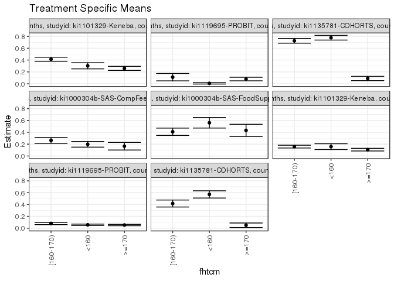

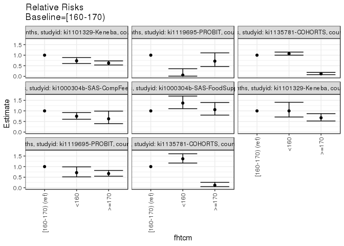

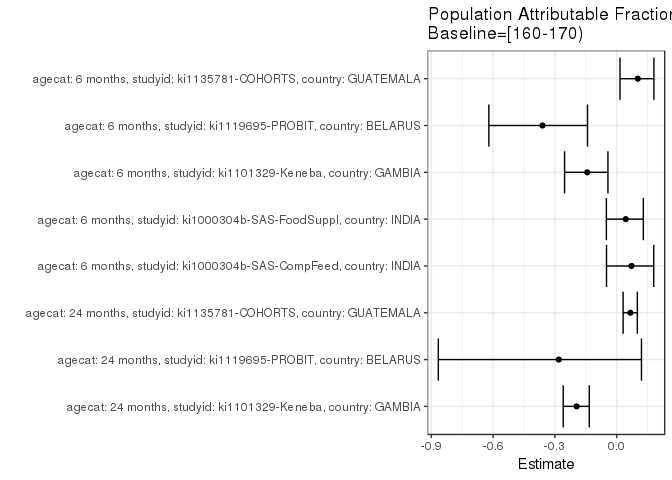

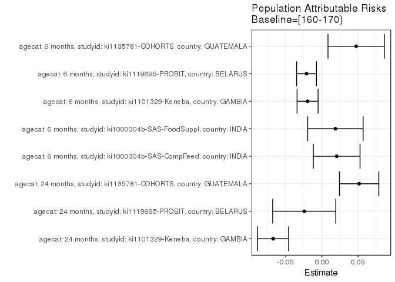

## Results Table

### Parameter: TSM

| agecat | studyid | country | intervention_level | baseline_level | estimate | ci_lower | ci_upper |
| --- | --- | --- | --- | --- | --- | --- | --- |
| 6 months | ki1000304b-SAS-CompFeed | INDIA | [160-170) | NA | 0.2632623 | 0.2139605 | 0.3125641 |
| 6 months | ki1000304b-SAS-CompFeed | INDIA | <160 | NA | 0.1969658 | 0.1492663 | 0.2446653 |
| 6 months | ki1000304b-SAS-CompFeed | INDIA | >=170 | NA | 0.1647301 | 0.1004209 | 0.2290394 |
| 6 months | ki1000304b-SAS-FoodSuppl | INDIA | [160-170) | NA | 0.4086850 | 0.3469040 | 0.4704659 |
| 6 months | ki1000304b-SAS-FoodSuppl | INDIA | <160 | NA | 0.5602541 | 0.4715741 | 0.6489342 |
| 6 months | ki1000304b-SAS-FoodSuppl | INDIA | >=170 | NA | 0.4326016 | 0.3298979 | 0.5353052 |
| 6 months | ki1101329-Keneba | GAMBIA | [160-170) | NA | 0.1580870 | 0.1345330 | 0.1816409 |
| 6 months | ki1101329-Keneba | GAMBIA | <160 | NA | 0.1580117 | 0.1090497 | 0.2069738 |
| 6 months | ki1101329-Keneba | GAMBIA | >=170 | NA | 0.1065420 | 0.0841725 | 0.1289115 |
| 6 months | ki1119695-PROBIT | BELARUS | [160-170) | NA | 0.0800490 | 0.0604816 | 0.0996163 |
| 6 months | ki1119695-PROBIT | BELARUS | <160 | NA | 0.0571609 | 0.0452499 | 0.0690718 |
| 6 months | ki1119695-PROBIT | BELARUS | >=170 | NA | 0.0536298 | 0.0418536 | 0.0654059 |
| 6 months | ki1135781-COHORTS | GUATEMALA | [160-170) | NA | 0.4168154 | 0.3580986 | 0.4755323 |
| 6 months | ki1135781-COHORTS | GUATEMALA | <160 | NA | 0.5708828 | 0.5097267 | 0.6320390 |
| 6 months | ki1135781-COHORTS | GUATEMALA | >=170 | NA | 0.0496436 | 0.0114487 | 0.0878386 |
| 24 months | ki1101329-Keneba | GAMBIA | [160-170) | NA | 0.4135670 | 0.3796232 | 0.4475108 |
| 24 months | ki1101329-Keneba | GAMBIA | <160 | NA | 0.3032313 | 0.2511908 | 0.3552718 |
| 24 months | ki1101329-Keneba | GAMBIA | >=170 | NA | 0.2592034 | 0.2250796 | 0.2933272 |
| 24 months | ki1119695-PROBIT | BELARUS | [160-170) | NA | 0.1110186 | 0.0486615 | 0.1733757 |
| 24 months | ki1119695-PROBIT | BELARUS | <160 | NA | 0.0065223 | -0.0049035 | 0.0179481 |
| 24 months | ki1119695-PROBIT | BELARUS | >=170 | NA | 0.0797355 | 0.0497021 | 0.1097690 |
| 24 months | ki1135781-COHORTS | GUATEMALA | [160-170) | NA | 0.7249743 | 0.6850941 | 0.7648544 |
| 24 months | ki1135781-COHORTS | GUATEMALA | <160 | NA | 0.7769961 | 0.7374612 | 0.8165310 |
| 24 months | ki1135781-COHORTS | GUATEMALA | >=170 | NA | 0.0882250 | 0.0519917 | 0.1244583 |

### Parameter: E(Y)

| agecat | studyid | country | intervention_level | baseline_level | estimate | ci_lower | ci_upper |
| --- | --- | --- | --- | --- | --- | --- | --- |
| 6 months | ki1000304b-SAS-CompFeed | INDIA | NA | NA | 0.2837670 | 0.2471555 | 0.3203786 |
| 6 months | ki1000304b-SAS-FoodSuppl | INDIA | NA | NA | 0.4274194 | 0.3770801 | 0.4777586 |
| 6 months | ki1101329-Keneba | GAMBIA | NA | NA | 0.1383190 | 0.1209060 | 0.1557320 |
| 6 months | ki1119695-PROBIT | BELARUS | NA | NA | 0.0588483 | 0.0462144 | 0.0714821 |
| 6 months | ki1135781-COHORTS | GUATEMALA | NA | NA | 0.4642857 | 0.4108803 | 0.5176911 |
| 24 months | ki1101329-Keneba | GAMBIA | NA | NA | 0.3461835 | 0.3202819 | 0.3720851 |
| 24 months | ki1119695-PROBIT | BELARUS | NA | NA | 0.0866485 | 0.0534930 | 0.1198040 |
| 24 months | ki1135781-COHORTS | GUATEMALA | NA | NA | 0.7765152 | 0.7409486 | 0.8120817 |

### Parameter: RR

| agecat | studyid | country | intervention_level | baseline_level | estimate | ci_lower | ci_upper |
| --- | --- | --- | --- | --- | --- | --- | --- |
| 6 months | ki1000304b-SAS-CompFeed | INDIA | [160-170) | [160-170) | 1.0000000 | 1.0000000 | 1.0000000 |
| 6 months | ki1000304b-SAS-CompFeed | INDIA | <160 | [160-170) | 0.7481732 | 0.6063512 | 0.9231666 |
| 6 months | ki1000304b-SAS-CompFeed | INDIA | >=170 | [160-170) | 0.6257262 | 0.3952785 | 0.9905252 |
| 6 months | ki1000304b-SAS-FoodSuppl | INDIA | [160-170) | [160-170) | 1.0000000 | 1.0000000 | 1.0000000 |
| 6 months | ki1000304b-SAS-FoodSuppl | INDIA | <160 | [160-170) | 1.3708704 | 1.1058037 | 1.6994750 |
| 6 months | ki1000304b-SAS-FoodSuppl | INDIA | >=170 | [160-170) | 1.0585208 | 0.8019959 | 1.3970974 |
| 6 months | ki1101329-Keneba | GAMBIA | [160-170) | [160-170) | 1.0000000 | 1.0000000 | 1.0000000 |
| 6 months | ki1101329-Keneba | GAMBIA | <160 | [160-170) | 0.9995240 | 0.7095821 | 1.4079388 |
| 6 months | ki1101329-Keneba | GAMBIA | >=170 | [160-170) | 0.6739453 | 0.5221212 | 0.8699172 |
| 6 months | ki1119695-PROBIT | BELARUS | [160-170) | [160-170) | 1.0000000 | 1.0000000 | 1.0000000 |
| 6 months | ki1119695-PROBIT | BELARUS | <160 | [160-170) | 0.7140740 | 0.5156975 | 0.9887613 |
| 6 months | ki1119695-PROBIT | BELARUS | >=170 | [160-170) | 0.6699620 | 0.5479574 | 0.8191313 |
| 6 months | ki1135781-COHORTS | GUATEMALA | [160-170) | [160-170) | 1.0000000 | 1.0000000 | 1.0000000 |
| 6 months | ki1135781-COHORTS | GUATEMALA | <160 | [160-170) | 1.3696298 | 1.1672315 | 1.6071240 |
| 6 months | ki1135781-COHORTS | GUATEMALA | >=170 | [160-170) | 0.1191022 | 0.0549206 | 0.2582880 |
| 24 months | ki1101329-Keneba | GAMBIA | [160-170) | [160-170) | 1.0000000 | 1.0000000 | 1.0000000 |
| 24 months | ki1101329-Keneba | GAMBIA | <160 | [160-170) | 0.7332097 | 0.6065566 | 0.8863088 |
| 24 months | ki1101329-Keneba | GAMBIA | >=170 | [160-170) | 0.6267507 | 0.5377098 | 0.7305361 |
| 24 months | ki1119695-PROBIT | BELARUS | [160-170) | [160-170) | 1.0000000 | 1.0000000 | 1.0000000 |
| 24 months | ki1119695-PROBIT | BELARUS | <160 | [160-170) | 0.0587499 | 0.0096013 | 0.3594877 |
| 24 months | ki1119695-PROBIT | BELARUS | >=170 | [160-170) | 0.7182179 | 0.4649139 | 1.1095321 |
| 24 months | ki1135781-COHORTS | GUATEMALA | [160-170) | [160-170) | 1.0000000 | 1.0000000 | 1.0000000 |
| 24 months | ki1135781-COHORTS | GUATEMALA | <160 | [160-170) | 1.0717568 | 1.0014029 | 1.1470534 |
| 24 months | ki1135781-COHORTS | GUATEMALA | >=170 | [160-170) | 0.1216939 | 0.0804457 | 0.1840921 |

### Parameter: PAR

| agecat | studyid | country | intervention_level | baseline_level | estimate | ci_lower | ci_upper |
| --- | --- | --- | --- | --- | --- | --- | --- |
| 6 months | ki1000304b-SAS-CompFeed | INDIA | [160-170) | NA | 0.0205047 | -0.0117868 | 0.0527962 |
| 6 months | ki1000304b-SAS-FoodSuppl | INDIA | [160-170) | NA | 0.0187344 | -0.0195908 | 0.0570596 |
| 6 months | ki1101329-Keneba | GAMBIA | [160-170) | NA | -0.0197680 | -0.0342925 | -0.0052435 |
| 6 months | ki1119695-PROBIT | BELARUS | [160-170) | NA | -0.0212007 | -0.0349266 | -0.0074748 |
| 6 months | ki1135781-COHORTS | GUATEMALA | [160-170) | NA | 0.0474703 | 0.0085034 | 0.0864371 |
| 24 months | ki1101329-Keneba | GAMBIA | [160-170) | NA | -0.0673835 | -0.0887930 | -0.0459740 |
| 24 months | ki1119695-PROBIT | BELARUS | [160-170) | NA | -0.0243701 | -0.0680077 | 0.0192675 |
| 24 months | ki1135781-COHORTS | GUATEMALA | [160-170) | NA | 0.0515409 | 0.0243434 | 0.0787384 |

### Parameter: PAF

| agecat | studyid | country | intervention_level | baseline_level | estimate | ci_lower | ci_upper |
| --- | --- | --- | --- | --- | --- | --- | --- |
| 6 months | ki1000304b-SAS-CompFeed | INDIA | [160-170) | NA | 0.0722590 | -0.0494523 | 0.1798547 |
| 6 months | ki1000304b-SAS-FoodSuppl | INDIA | [160-170) | NA | 0.0438314 | -0.0500638 | 0.1293306 |
| 6 months | ki1101329-Keneba | GAMBIA | [160-170) | NA | -0.1429159 | -0.2530041 | -0.0425000 |
| 6 months | ki1119695-PROBIT | BELARUS | [160-170) | NA | -0.3602604 | -0.6206323 | -0.1417201 |
| 6 months | ki1135781-COHORTS | GUATEMALA | [160-170) | NA | 0.1022437 | 0.0162447 | 0.1807247 |
| 24 months | ki1101329-Keneba | GAMBIA | [160-170) | NA | -0.1946467 | -0.2595930 | -0.1330491 |
| 24 months | ki1119695-PROBIT | BELARUS | [160-170) | NA | -0.2812523 | -0.8660445 | 0.1202742 |
| 24 months | ki1135781-COHORTS | GUATEMALA | [160-170) | NA | 0.0663746 | 0.0312270 | 0.1002470 |